# Data Skills Week 4 - R Analysis

Author

Graham Bishop

Published

September 1, 2026

Modified

September 17, 2026

Abstract

Sample Analysis for Dataskills Week 4

## Step 0: Installing packages

Install packages by running the following chunk (click the green triangle):

```r
# Install pacman if you don't have it
if (!requireNamespace("pacman", quietly = TRUE)) install.packages("pacman")

# Installs (if needed) and loads all listed packages
pacman::p_load(morrowplots, ggplot2, dplyr, renv, here)
```

## Step 1: Setting up - the YAML header

Let’s look at the YAML header. Notice there is a `date` field. Render the document and examine how the `date` field is rendered. This is when the document was first authored. Since we are modifying it today, let’s add another line to the header with today’s date. Add the following to the header:

date-modified: “2026-09-17”

Now re-render the document. Answer the following question:

*Q1. What happened when you added the `date-modified` line to the YAML header? Keep the > symbol in your answer.*

> It now has two columns under the title. The first says ‘PUBLISHED’ with the original date and the second column says ‘MODIFIED’ with today’s date.

Let’s add some more information. Add your name via an `author:` tag, as well as a very brief `abstract:`. Both of these should go in the YAML header below your date lines. Click render and observe the result.

You can read more about the many options for HTML files [here](https://quarto.org/docs/reference/formats/html.html).

## Step 2: Analysis

Let’s run a basic analysis and output some results. Read and run the chunk below.

```r
# Let's examine the morrowplots data

# Look at first few rows
head(morrowplots)
```

```
# A tibble: 6 × 26
  phase  year plot  plot_num plot_dir rotation corn  crop  variety      all_corn
  <dbl> <dbl> <chr>    <dbl> <chr>       <dbl> <lgl> <chr> <chr>        <lgl>
1     1  1888 3NA          3 NW              1 TRUE  CC    Burr's White FALSE
2     1  1888 3NB          3 NW              1 TRUE  CC    Burr's White FALSE
3     1  1888 3NC          3 NE              1 TRUE  CC    Burr's White FALSE
4     1  1888 3ND          3 NE              1 TRUE  CC    Burr's White FALSE
5     1  1888 3SA          3 SW              1 TRUE  CC    Burr's White FALSE
6     1  1888 3SB          3 SW              1 TRUE  CC    Burr's White FALSE
# ℹ 16 more variables: yield_bush <dbl>, yield_ton <dbl>, treated <lgl>,
#   treatment <chr>, manure <dbl>, lime <dbl>, nit <dbl>, p205 <dbl>,
#   k20 <dbl>, stover <dbl>, population <dbl>, plant_date <chr>,
#   plant_day <dbl>, soil_sample <lgl>, damage <chr>, notes <chr>
```

```r
# Output a summary of different column variables
summary(morrowplots)
```

```
     phase            year             plot         plot_num      plot_dir
 Min.   :1.000   Min.   :1888   Length   :3216   Min.   :3   Length   :3216
 1st Qu.:2.000   1st Qu.:1921   N.unique :  24   1st Qu.:3   N.unique :   4
 Median :2.500   Median :1954   N.blank  :   0   Median :4   N.blank  :   0
 Mean   :2.963   Mean   :1954   Min.nchar:   3   Mean   :4   Min.nchar:   2
 3rd Qu.:4.000   3rd Qu.:1988   Max.nchar:   3   3rd Qu.:5   Max.nchar:   2
 Max.   :5.000   Max.   :2021                    Max.   :5

    rotation       corn                crop           variety
 Min.   :1.00   Mode :logical   Length   :3216   Length   :3216
 1st Qu.:1.00   FALSE:1176      N.unique :   6   N.unique :  45
 Median :2.00   TRUE :1951      N.blank  :   0   N.blank  :   0
 Mean   :1.99   NAs  :89        Min.nchar:   1   Min.nchar:   4
 3rd Qu.:3.00                   Max.nchar:   2   Max.nchar:  27
 Max.   :3.00                   NAs      :  89   NAs      :1874
 NAs    :89
  all_corn         yield_bush      yield_ton      treated
 Mode :logical   Min.   :  0.0   Min.   : 0.26   Mode :logical
 FALSE:2575      1st Qu.: 35.9   1st Qu.: 1.12   FALSE:1540
 TRUE :552       Median : 53.7   Median : 1.75   TRUE :1587
 NAs  :89        Mean   : 68.8   Mean   : 2.92   NAs  :89
                 3rd Qu.: 86.4   3rd Qu.: 3.54
                 Max.   :327.0   Max.   :51.55
                 NAs    :502     NAs    :3012
     treatment        manure           lime            nit
 Length   :3216   Min.   :150.0   Min.   :1.000   Min.   : 25.0
 N.unique :   8   1st Qu.:494.2   1st Qu.:2.000   1st Qu.:200.0
 N.blank  :   0   Median :600.0   Median :3.000   Median :200.0
 Min.nchar:   3   Mean   :583.7   Mean   :3.013   Mean   :191.2
 Max.nchar:   8   3rd Qu.:600.0   3rd Qu.:4.000   3rd Qu.:200.0
 NAs      :  89   Max.   :980.0   Max.   :5.000   Max.   :300.0
                  NAs    :3060    NAs    :3177    NAs    :2781
      p205             k20            stover        population
 Min.   : 40.00   Min.   : 30.0   Min.   :0.190   Min.   :   100
 1st Qu.: 40.00   1st Qu.: 30.0   1st Qu.:1.292   1st Qu.: 12000
 Median : 59.64   Median :100.0   Median :1.882   Median : 16000
 Mean   :104.76   Mean   :113.9   Mean   :2.214   Mean   : 19456
 3rd Qu.:200.00   3rd Qu.:200.0   3rd Qu.:2.917   3rd Qu.: 24000
 Max.   :200.00   Max.   :200.0   Max.   :6.950   Max.   :175000
 NAs    :2994     NAs    :2964    NAs    :3058    NAs    :2315
     plant_date     plant_day     soil_sample           damage
 Length   :3216   Min.   : 59.0   Mode :logical   Length   :3216
 N.unique : 102   1st Qu.:116.0   FALSE:2326      N.unique :   5
 N.blank  :   0   Median :126.0   TRUE :890       N.blank  :   0
 Min.nchar:   8   Mean   :122.9                   Min.nchar:  12
 Max.nchar:  10   3rd Qu.:134.0                   Max.nchar:  57
 NAs      :1842   Max.   :157.0                   NAs      :3197
                  NAs    :1864
       notes
 Length   :3216
 N.unique :  10
 N.blank  :   0
 Min.nchar:  11
 Max.nchar: 194
 NAs      :3127
```

Create a code chunk using the code below and save the `morrowplots` data frame as a CSV file in your project directory in an appropriate location. This assumes you have a `data` directory in your project; modify as needed. Note the use of the `here` package, which helps simplify relative file paths.

```r
write.csv(morrowplots,here("data","morrowplots.csv"))
```

### Inserting text inline using code

We can insert text into our writing by providing R code inline. For example, if I wanted to write a sentence about the size of the `morrowplots` dataset, I could do the following:

The `morrowplots` dataset has 3216 rows and 26 columns.

*Q2. Render the document. Which values were inserted when you rendered the line above? (Keep the > symbol in your answer.)*

> `nrow(morrowplots)` rendered to say ‘3216’ and `ncol(morrowplots)` was replaced with ‘26’.

### Generating some plots

Let’s make some plots. We’ll use the packages `ggplot2` and `dplyr` for this.

We are going to make some visualizations from the `morrowplots` [vignette](https://cran.r-project.org/web/packages/morrowplots/vignettes/morrow-plots-data-visualizations.html). Note that the following code chunk has two parameters specified (`label` and `echo`). The `label` parameter names the chunk.

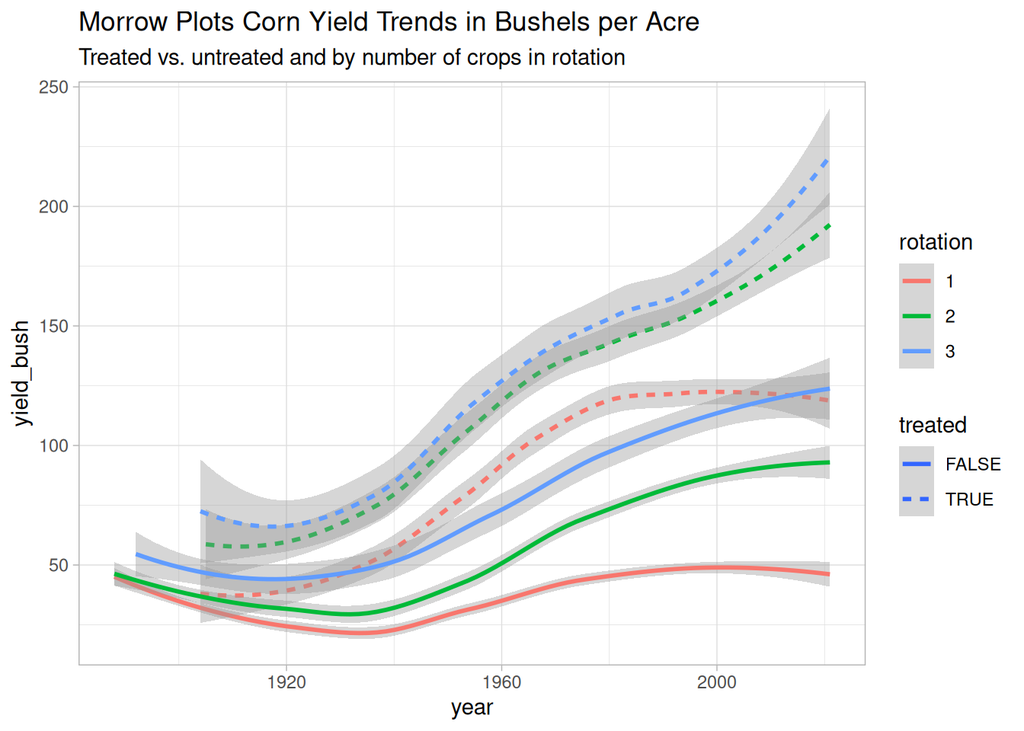

Figure 1: “Treated vs. untreated and by number of crops in rotation. Treated corn produces higher yields than untreated corn, and continuous corn provides the lowest yields. Corn in a 2-crop rotation performs better, and corn in a 3-crop rotation performs best.”

Render the document.

*Q3. Does the code to generate the figure appear above the figure? (Keep the > symbol in your answer.)*

> Above the figure, it has the whole code box and some text that says: `geom_smooth()` using method = ‘loess’ and formula = ‘y ~ x’

Now, change `echo: true` to `echo: false` in the above code chunk and render again.

*Q4. Does the code to generate the figure still appear above the figure? (Keep the > symbol in your answer.)*

> Now, the code box is gone and just that message and the figure remains.

Now, let’s change the chunk label from `label: corn-yield-trends` to `label: fig-corn-yield-trends`.

Let’s also add another parameter for a caption. Add the following text below the label:

#| fig-cap: “Treated vs. untreated and by number of crops in rotation. Treated corn produces higher yields than untreated corn, and continuous corn provides the lowest yields. Corn in a 2-crop rotation performs better, and corn in a 3-crop rotation performs best.”

Render the document again. A caption should now appear.

*Q5. Is the figure automatically numbered?*

> Yes, it says, ‘Figure 1’ even though that is not explicitly in the caption I pasted.

With our figure now numbered, we can render the figure number automatically in our document using the @ sign. This is very powerful. Here is an example:

In this report, Figure 1 demonstrates that we can render figures and link to them elsewhere in our document.

*Q6. Once you render the report and view the HTML file, what appears in place of `@fig-corn-yield-trends` above? What happens when you hover and click on it?*

> Whoa, it says ‘Figure 1’, highlighted like a link. When I hover over it, the Figure and caption appear in a popup. If i click on it, it brings me back up to the figure.

*Q7. What is one potential advantage of generating figures on the fly in a notebook?*

> If the data changes, such as a new year of data being added to the `morrowplots` dataset, then the figure will automatically include that new data the next time it is rendered.

## Step 3: Environment

For your analysis to be reproducible, it is important to keep track of package versions. As package versions change, so may their functions and data. We can do this with the package `renv`. Run the following to load `renv`:

You know, I don’t think we really need to have the code for loading the package in our report. Add `echo: false` to the above chunk, just like for the corn-yield-trends chunk.

*Q8. After adding echo: false and rendering, is the code above rendered in the report? (Keep the > symbol in your answer.)*

> The code cell that said, ‘library(renv)’ is no longer rendered.

The code should no longer be rendered, but there are some R messages still printed. We can hide these by also adding `message: false`.

Now let’s move on to `renv`. The chunk below will not be run automatically when the document is rendered due to the `eval: false` parameter. Run the following command manually in your R console. Note: you will need to have the RStudio project loaded for this to work properly, since your working directory must be appropriately set.

```r
renv::init()
```

What just happened? `renv` just magically detected all of the packages being used by your project and installed them into your very own **project library**, located at `renv/library`. Just like `conda` with Python, this allows you to have different projects with different versions of packages. Installing, updating, or removing packages in one project won’t affect other projects. It also created a `renv.lock` file, which includes all the metadata about each package needed to recreate your environment. If you like, peek inside the file to see what this consists of. You can read about this in detail in the [package documentation](https://rstudio.github.io/renv/articles/renv.html).

Git commit and push. Now your entire R environment is permanently saved and can be recreated by a future version of yourself or someone looking to reproduce your analysis. Exciting stuff.

Now, let’s install and load one more package. Set `eval` to `true` in the code chunk below and run the code chunk manually.

```r
if (!"uiucthemes" %in% installed.packages()) {
  install.packages('uiucthemes')
}

library(uiucthemes)
```

After setting `eval` to `true` in the chunk above, *save this notebook file* and run the command `renv::snapshot()` in your Console. This takes a new snapshot of your currently installed packages and saves them to `renv.lock`. Hit Y to proceed if prompted.

*Q9. Check GitHub Desktop. Describe the changes that have now been made to `renv.lock`. Why did these packages not get recorded earlier?*

> The changes to the renv.lock include adding a few packages to the ‘Packages’ object. Each one has a bunch of attributes like ‘Package’, ‘Version’, ‘Source’, etc. They also include what other packages they depend on, import, or suggest. They did not get recorded earlier because I installed the packages locally, but renv::snapshot() records the packages that are installed and being used, and then writes them to renv.lock, so the changes didn’t appear until I did that.

In order to recreate your environment, your collaborator will need to clone your repository and run `renv::restore()` to recreate your environment. Feel free to try it on another computer if you like (not part of this lab).

## Render and submit

Once you are done, click “Render” to create an HTML file that includes all of your answers to the questions in this document. You will upload this HTML file to Canvas.

## Optional: Render as PDF

Quarto supports many different formats. Let’s close by rendering this document a PDF. Replace `format: html` with `format: pdf` in the YAML header and click Render. You may need to have LaTex installed. If this does not work on your computer, don’t worry - this is not required for today’s lab.

## Resources

- [Quarto getting started in RStudio](https://quarto.org/docs/get-started/hello/rstudio.html)
- [Quarto introduction](https://r4ds.hadley.nz/quarto.html)
- [Quarto reference](https://quarto.org/docs/reference/)
- [Markdown reference](https://commonmark.org/help/)